# Práctica 3 ejercicio 4

Ejercicio 4: Variable aleatoria Y: Rendimiento de la reacción química (diferencia entre el rendimiento teórico y el observado). Es una variable cuantitativa continua.

Factores en estudio:

- Temperatura: cuantitativa

Niveles: 50, 75 y 100 ºC

- Compuesto B: cuantitativa

Niveles: 40, 60 y 80%.

No hay factor de bloqueo.

Análisis descriptivo del conjunto de datos:

| Temperatura | Porcentaje | Media | SD | Mediana | Rango |
| --- | --- | --- | --- | --- | --- |
| 100 | 40 | 15.0 | 1.4142136 | 15.0 | 2 |
| 100 | 60 | 19.5 | 2.1213203 | 19.5 | 3 |
| 100 | 80 | 24.0 | 1.4142136 | 24.0 | 2 |
| 50 | 40 | 12.0 | 1.4142136 | 12.0 | 2 |
| 50 | 60 | 15.5 | 0.7071068 | 15.5 | 1 |
| 50 | 80 | 17.0 | 1.4142136 | 17.0 | 2 |
| 75 | 40 | 10.5 | 2.1213203 | 10.5 | 3 |
| 75 | 60 | 13.5 | 0.7071068 | 13.5 | 1 |
| 75 | 80 | 16.0 | 1.4142136 | 16.0 | 2 |

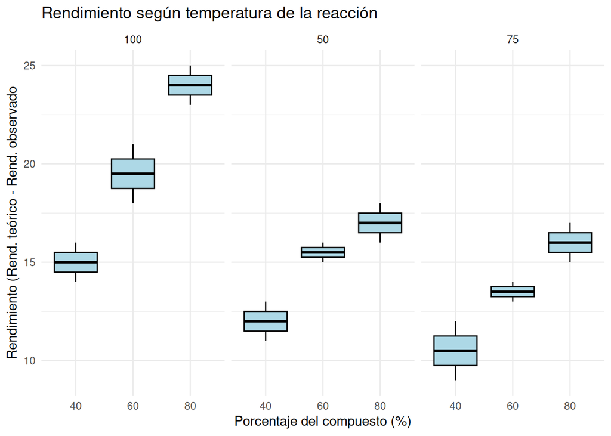

Evaluación de la interacción entre factores

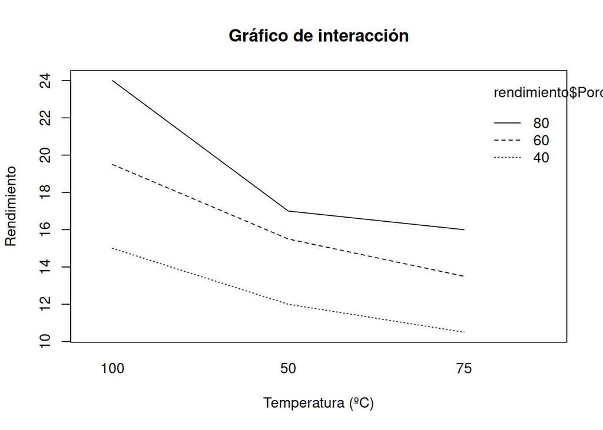

Se observa una pendiente más pronunciada para el rendimiento de la reacción en el cambio de temperatura entre 50 y 75ºC para un porcentaje de B=60%.

```
                       Df Sum Sq Mean Sq F value   Pr(>F)
Temperatura             2 124.11   62.06   27.93 0.000138 ***
Porcentaje              2 127.44   63.72   28.68 0.000125 ***
Temperatura:Porcentaje  4  10.22    2.56    1.15 0.393479
Residuals               9  20.00    2.22
---
Signif. codes:  0 '***' 0.001 '**' 0.01 '*' 0.05 '.' 0.1 ' ' 1
```

Analizando detalladamente la salida del cuadro ANOVA, encontramos que no es significativa la interacción entre las variables *Temperatura* y *Porcentaje*. Por lo que podemos resumir el modelo a uno sin interacción.

```
            Df Sum Sq Mean Sq F value   Pr(>F)
Temperatura  2 124.11   62.06   26.69 2.50e-05 ***
Porcentaje   2 127.44   63.72   27.41 2.17e-05 ***
Residuals   13  30.22    2.32
---
Signif. codes:  0 '***' 0.001 '**' 0.01 '*' 0.05 '.' 0.1 ' ' 1
```

Para la verificación del cumplimiento de supuestos del modelo, analizamos: - Linealidad y homocedasticidad: residuales vs ajustados.

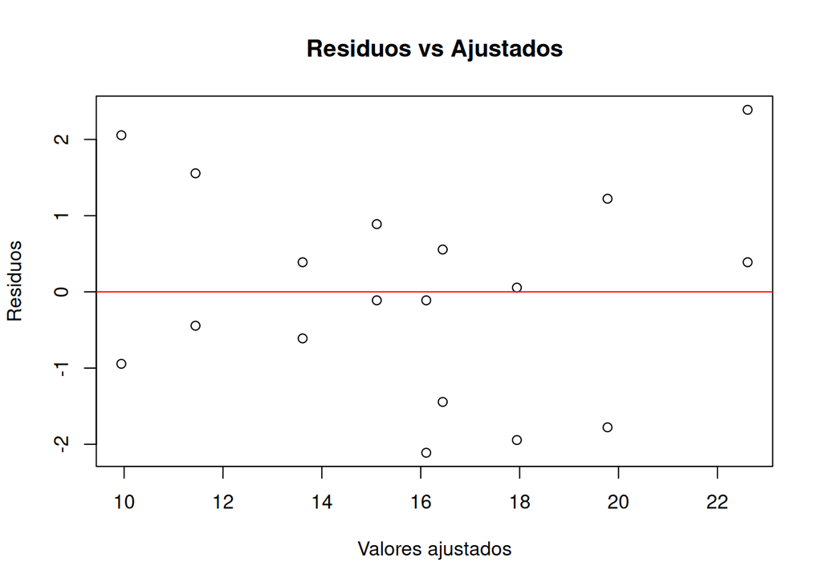

Se observa una distribución *aleatoria* en torno al valor esperado (0).  
- Normalidad

```
    Shapiro-Wilk normality test

data:  modelo_2$residuals
W = 0.97156, p-value = 0.8265
```

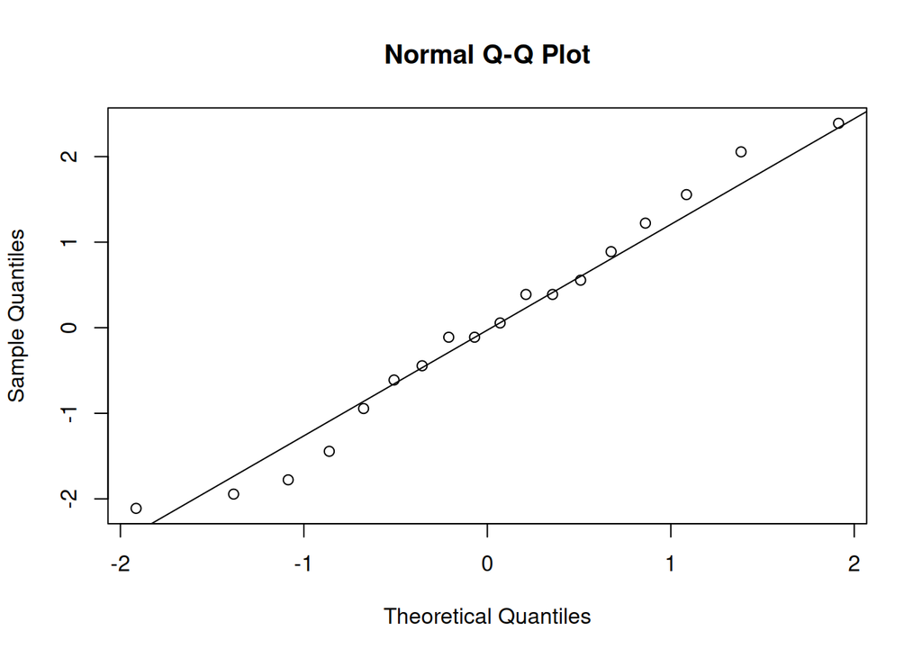

Debido a que el p-value>0.05, no rechazamos la hipótesis de normalidad.

- Independencia  
  Podemos asumir independencia porque la asignación del tratamiento fue aleatorizada. Análisis de comparaciones múltiples

Entonces, revisando la salida de R podemos representar al modelo como:

```
Call:
aov(formula = Respuesta ~ Temperatura + Porcentaje, data = rendimiento)

Residuals:
     Min       1Q   Median       3Q      Max
-2.11111 -0.86111 -0.02778  0.80556  2.38889

Coefficients:
              Estimate Std. Error t value Pr(>|t|)
(Intercept)    16.1111     0.8036  20.049 3.68e-11 ***
Temperatura50  -4.6667     0.8803  -5.301 0.000144 ***
Temperatura75  -6.1667     0.8803  -7.005 9.27e-06 ***
Porcentaje60    3.6667     0.8803   4.165 0.001109 **
Porcentaje80    6.5000     0.8803   7.384 5.32e-06 ***
---
Signif. codes:  0 '***' 0.001 '**' 0.01 '*' 0.05 '.' 0.1 ' ' 1

Residual standard error: 1.525 on 13 degrees of freedom
Multiple R-squared:  0.8927,    Adjusted R-squared:  0.8597
F-statistic: 27.05 on 4 and 13 DF,  p-value: 3.392e-06
```

Evaluación de efectos no lineales

|  | Res.Df | RSS | Df | Sum of Sq | F | Pr(>F) |
| --- | --- | --- | --- | --- | --- | --- |
| 1 | 15 | 89.69444 | NA | NA | NA | NA |
| 2 | 13 | 30.22222 | 2 | 59.47222 | 12.7909 | 0.0008494651 |

Podemos concluir que hay evidencia de efectos no lineales.  
Análisis de la combinación de Temperatura y Porcentaje que minimiza la diferencia entre el Rendimiento teórico y el observado.

```
 Temperatura Porcentaje emmean    SE df lower.CL upper.CL
 100         40          16.11 0.804 13    14.38     17.8
 50          40          11.44 0.804 13     9.71     13.2
 75          40           9.94 0.804 13     8.21     11.7
 100         60          19.78 0.804 13    18.04     21.5
 50          60          15.11 0.804 13    13.38     16.8
 75          60          13.61 0.804 13    11.88     15.3
 100         80          22.61 0.804 13    20.88     24.3
 50          80          17.94 0.804 13    16.21     19.7
 75          80          16.44 0.804 13    14.71     18.2

Confidence level used: 0.95
```

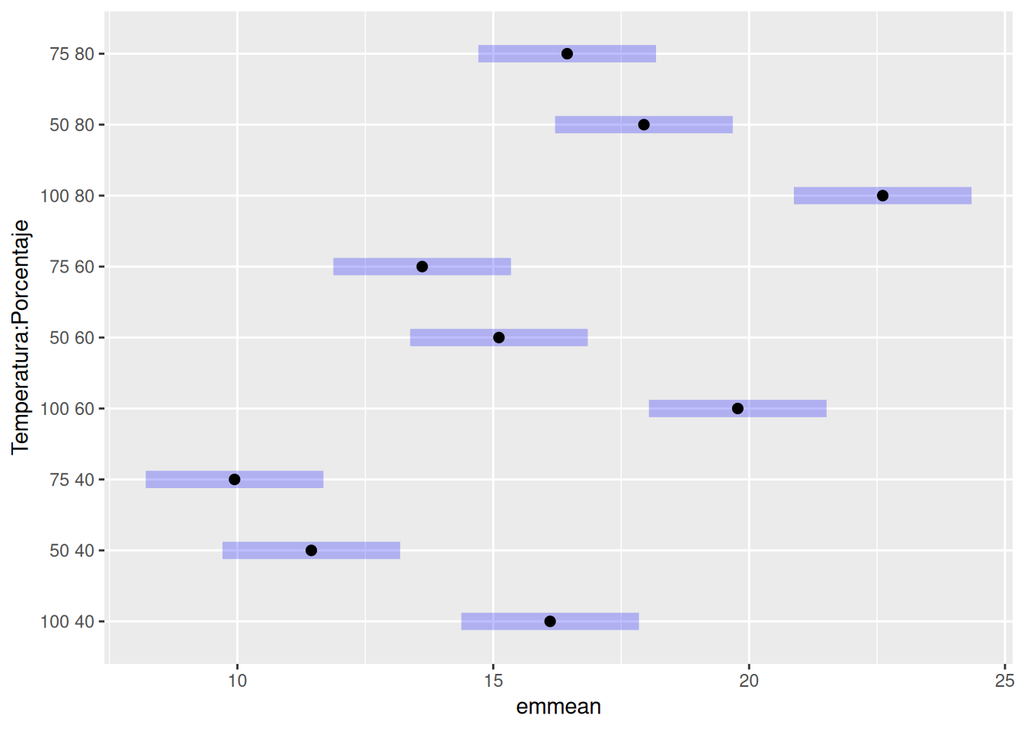

Concluimos que la combinación de 75ºC de temperatura y un 40% del compuesto B minimiza la diferencia entre el teórico y el observado.